# Software Tools, R - MidTerm Project

**Due date** : 25 Dec 2020, 23:59

#### **Objectives**

- Manage Working Directory, R-Files and R-Projects
- Download, Copy, Paste and Find the Data
- Read and Write Data
- Identify and Indexing Data
- Use Logical Operators
- Create a Function
- Plot the Data

**Hints** : You can use these functions and the main web page of our course - [LINK](https://emirtoker.github.io/Software_Tools_R_Github/r_language.html)

```
getwd()
setwd()
list.files()
file.path()

read.csv()
read.delim()
read.table()

class()
str()
length()
sim()
attributes()
attr()
typeof()

mean()
sum()
colMeans()
rowMeans()

na.omit()

plot()
View()
```

# **Instructions**

### **PART-1 Download, Get or Find and Read Data**

R-STUDIO AND DATA

1. Go to the [webpage](https://emirtoker.github.io/Software_Tools_R_Github/index.html) of the course
2. Open Data “Istanbul_Goztepe_Mean_Temperature_1839-2013_Monthly” (.dat) by click the LINK
3. Copy and Paste it in your “Downloads” directory in a text file with “.dat” extension
4. Open your R-Studio, Create an R-Project, Create an R-Script (*you will write and save your all codes from now in this script*), and try to read the data file with each of these ways:

WAY 1 - **GO TO FILE**

5. Check your Project Name and your Working directory
6. Go to “Downloads” directory in R-Studio, using console
7. List files and Read Data with three different read functions ( *read.csv(), read.delim(), read.table()*)
8. Choose the best for you ( *or change the options if it is necessary, regarding header or separators* )
9. Assign your data as “temp_1”

WAY 2 - **CALL THE FILE**

10. Go Back to your Working directory
11. Define your data file path with file.path() ( *remember, you downloaded the data in your Downloads folder* )
12. Assign the path a new variable as “path_my_file”
13. Use your best read…() function to read the file with “path_my_file”
14. Assign your data as “temp_2”

WAY 3 - **IMPORT THE FILE**

15. Use “Import Datase”
16. Chose “From Text (base)” option
17. Try to assign your data as “temp_3” at this time

WAY 4 - **GET THE FILE (WITH URL)**

18. Copy the LINK of data
19. Use your best read() function
20. Read the file with this function and LINK
21. Assign your data as “temp_4”

LAST STEP

22. Choose your favorite data ( *temp_1, temp_2, temp_3 or temp_4* ) and assign as just “**temp**”

### **PART-2 Play with the Data**

MEET WITH THE DATA

1. Look at class and structure
2. Learn attributes and dimensions
3. Rename attributes ( *ex: Months for each column and years for each raw* ) ( *attributes() and month.name or month.abb* )
- *By the way, your data have to include just temperature values when you print it. Years and months have to be just attributes of data.*

CLEAR **NA** AND CHOOSE COLUMN

4. Print “temp”. Do you see irrelevant numbers ? If so, change them as **NA**
- *Now your “temp” data must seem like this*

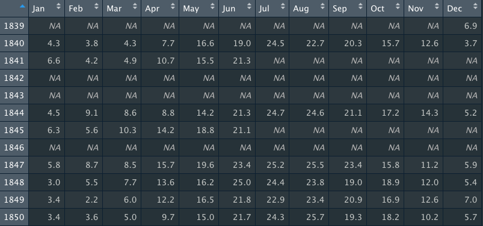

5. Delete rows which include NA ( *which() or na.omit()* )
- *Now your “temp” data must seem like this*

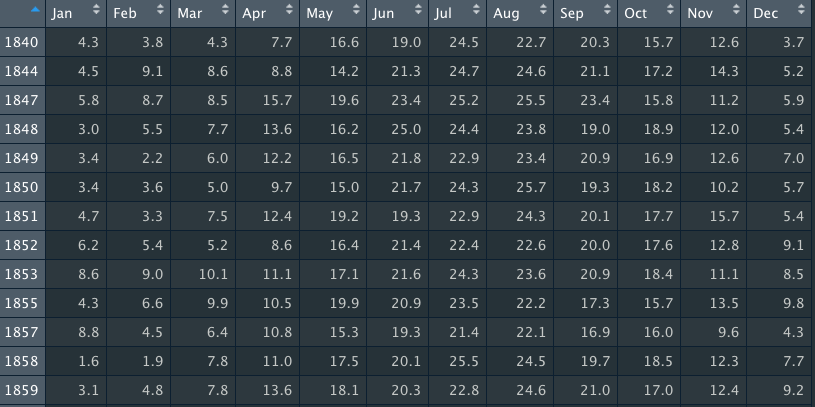

6. Assign it as new “temp” again
7. Select summer season
8. Assign it as “temp_summer” ( *three months*)

PLOT

14. Plot temperature for June ( *for each year* ), add title and unit
15. Edit y-axis and x-axis label ( *to see which years are they* )
16. What about July and August ? Plot them on the same figure with June.
17. Is there any strangeness thing, what do you think ? Compare three plots
18. Plot “avg_month”, make the type of line as “line” and colorful. What is reason of the *inverted V letter* shape
19. Plot “avg_year”, make the line dashed line. What do you think
20. Plot just temperature for just 1990 ( *my birth year* )

THE LAST BUT NOT LEAST

21. **Run these codes.** Can you explain what am I doing with my codes which were given below? What are these x-axis and y-axis in here? ( *which years or months are they?* ) What is the result of this figure, what do you see and what do you think? what do colors mean? Can you edit title and x-axis and y-axis labels?

```
plot(seq(1,12),  temp[142,1:12] , type = "l", col = "red")
lines(seq(1,12), temp[1,1:12]   , type = "l", col = "blue")
legend("topleft",c("blue","red"),fill=c("blue","red"))
abline(h = mean(colMeans(temp, na.rm = T)))
```

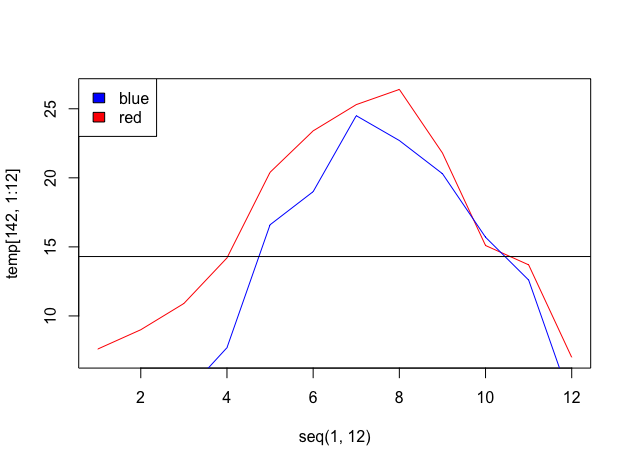

```
par(mfrow = c(2, 2))    #or try par(mfrow = c(4, 1))
plot(ylim = c(0,30), rowMeans(temp[,9:11])      , type="l", col="orange")
plot(ylim = c(0,30), rowMeans(temp[,c(12,1,2)]) , type="l", col="blue")
plot(ylim = c(0,30), rowMeans(temp[,3:5])       , type="l", col="green")
plot(ylim = c(0,30), rowMeans(temp[,6:8])       , type="l", col="red")
```

[figure not shown]

*For questions or problems, please use Ninova*

*Emir*